# Análise de Sentimento em Avaliações de Consumidores

O objetivo deste trabalho é aplicar técnicas de mineração de texto e análise de sentimento para avaliar a opinião dos consumidores sobre produtos ou serviços. O dataset utilizado pode ser encontrado em: https://www.kaggle.com/datasets/kaggle/us-consumer-finance-complaints.

O conjunto de dados “US Consumer Finance Complaints” contém reclamações dos consumidores sobre produtos e serviços financeiros nos Estados Unidos, juntamente com as respostas das empresas correspondentes. Essas reclamações são coletadas pelo Consumer Financial Protection Bureau (CFPB) e são disponibilizadas ao público após a resposta da empresa ou após 15 dias, o que ocorrer primeiro. Ao adicionar suas vozes, os consumidores contribuem para melhorar o mercado financeiro. Este conjunto de dados oferece uma visão valiosa das preocupações dos consumidores e das práticas das empresas no setor financeiro dos Estados Unidos.

# Instalação e carregamento de pacotes necessários

```r
#instalação
#install.packages("tidyverse")
#install.packages("tm")
#install.packages("SnowballC")
#install.packages("wordcloud")
#install.packages("sentimentr")
#install.packages("textTinyR")
#install.packages("tidytext")
#install.packages("textdata")
#install.packages("dplyr")
#install.packages("ggplot2")
#install.packages("kableExtra")
#bibliotecas
library(tidyverse)
library(tm)
library(SnowballC)
library(wordcloud)
library(sentimentr)
library(dplyr)
library(ggplot2)
library(textTinyR)
library(tidytext)
library(textdata)
library(kableExtra)
```

# Importação e Pré-processamento

```r
complaints <- read.csv("consumer_complaints.csv", stringsAsFactors = FALSE)
complaints_narrative_vazia <- subset(complaints, consumer_complaint_narrative == "")
complaints <- complaints[-which(complaints$consumer_complaint_narrative == ""), ]
```

# Criação do corpus de texto

```r
consumer_corpus <- VCorpus(VectorSource(complaints$consumer_complaint_narrative))
preprocess_text <- function(corpus) {
  corpus <- tm_map(corpus, content_transformer(tolower))
  corpus <- tm_map(corpus, removePunctuation)
  #corpus <- tm_map(corpus, wordTokenize)
  corpus <- tm_map(corpus, removeNumbers)
  corpus <- tm_map(corpus, stripWhitespace)
  return(corpus)}
consumer_corpus <- preprocess_text(consumer_corpus)
consumer_corpus
```

```
## <<VCorpus>>
## Metadata:  corpus specific: 0, document level (indexed): 0
## Content:  documents: 66806
```

# Distribuição de Reclamações por Produto

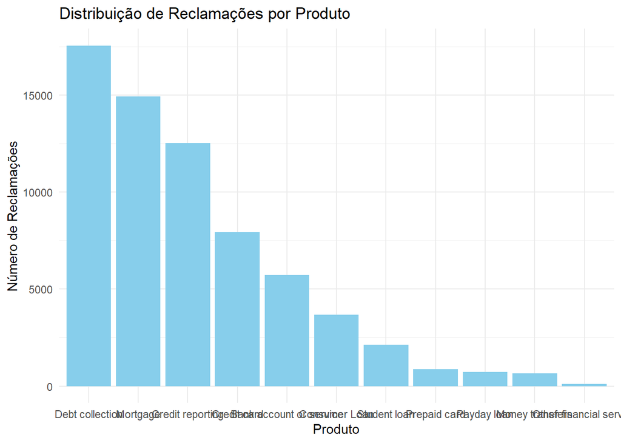

```r
complaints_by_product <- complaints %>%
  count(product) %>%
  arrange(desc(n))
ggplot(complaints_by_product, aes(x = reorder(product, -n), y = n)) +
  geom_bar(stat = "identity", fill = "skyblue") +
  labs(title = "Distribuição de Reclamações por Produto",
       x = "Produto", y = "Número de Reclamações") +
  theme(axis.text.x = element_text(angle = 45, hjust = 1)) +
  theme_minimal()
```

O gráfico acima mostra a distribuição de reclamações agrupadas por produto da base de dados.

# Distribuição de Reclamações por Empresa (Top 10)

```r
complaints_by_company <- complaints %>% count(company) %>% arrange(desc(n)) %>%
  top_n(10)
```

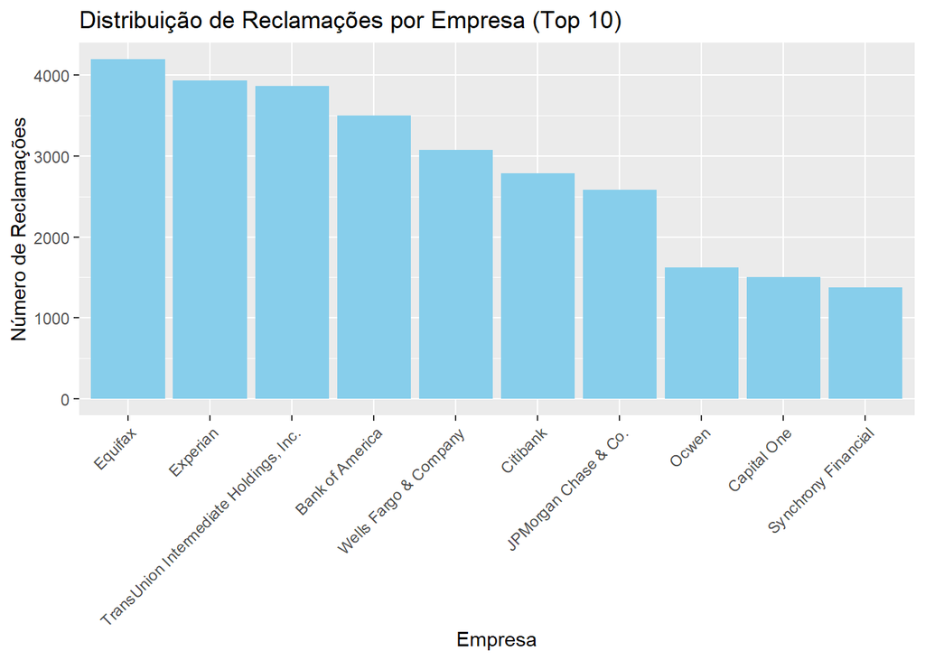

```r
ggplot(complaints_by_company, aes(x = reorder(company, -n), y = n, fill = company)) +
  geom_bar(stat = "identity", fill = "skyblue") +
  labs(title = "Distribuição de Reclamações por Empresa (Top 10)",
       x = "Empresa", y = "Número de Reclamações") +
  theme(axis.text.x = element_text(angle = 45, hjust = 1)) + theme(legend.position = "none")
```

O gráfico acima está representando as 10 maiores empresas por reclamações no *dataset*.

# Análise de Sentimento

```r
library(tidytext)
afinn <- get_sentiments("afinn")
dtm_cor <- DocumentTermMatrix(consumer_corpus)
voc <- intersect(Terms(dtm_cor), afinn$word)
dtm_dic <- DocumentTermMatrix(x = consumer_corpus, control =  list(dictionary = voc))
afinn <- subset(afinn, word %in% voc)
lex <- data.frame(term = voc, y = afinn$value)
m <- as.matrix(dtm_dic)
pol <- (m %*% cbind(lex$y))/rowSums(m)
fra <- (substr(complaints$consumer_complaint_narrative, start = 1, stop = 60))
df <- data.frame(pol, fra)
head(df)
```

```
##          pol                                                          fra
## 1 -1.0000000 XXXX has claimed I owe them {$27.00} for XXXX years despite
## 2  0.0000000 Due to inconsistencies in the amount owed that I was told by
## 3  0.2083333 In XX/XX/XXXX my wages that I earned at my job decreased by
## 4        NaN I have an open and current mortgage with Chase Bank # XXXX.
## 5 -0.2000000 XXXX was submitted XX/XX/XXXX. At the time I submitted this
## 6 -0.5000000 Experian is reporting my OPEN and CURRENT Mortgage loan with
```

# Densidade da Polaridade do Sentimento

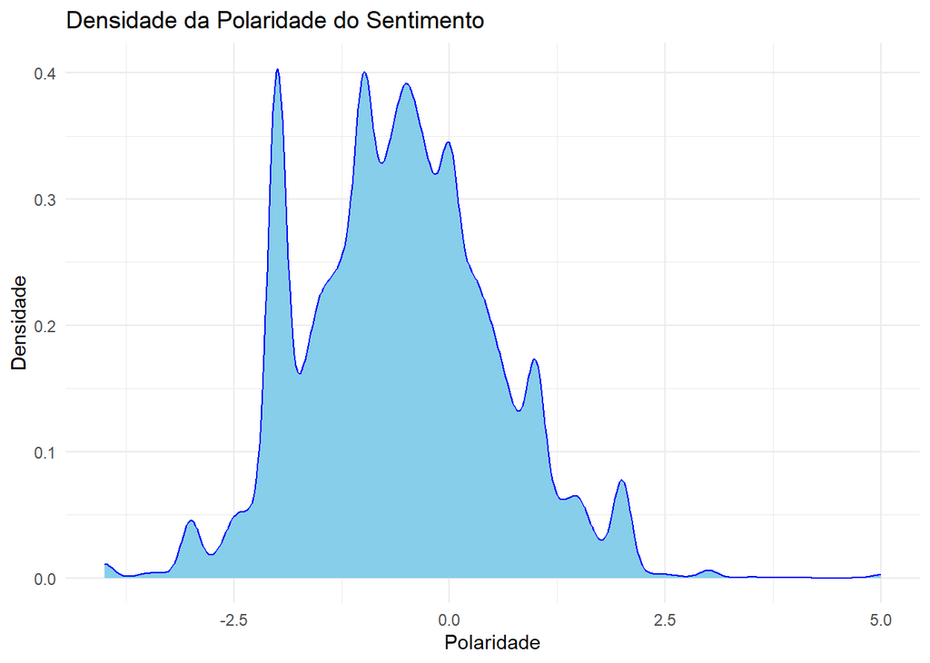

```r
ggplot(df, aes(x = pol)) +
  geom_density(fill = "skyblue", color = "blue") +
  labs(title = "Densidade da Polaridade do Sentimento",
       x = "Polaridade",
       y = "Densidade") +
  theme_minimal()
```

O gráfico acima mostra a distribuição da polaridade do sentimento atribuído a cada uma das reclamações da base de dados. Como visto acima, a polaridade se concentra negativamente.